# Aula 3

## IEE065 - Análise de Sobrevivência e Confiabilidade

#### Aluno: João Claudio da Silva Araujo Lobato

##### Amazoneida Sá Peixoto Pinheiro - Professora Associada do Depto. Estatística - UFAM

### Aula-03: Fundamentos da Análise de Sobrevivência e Confiabilidade

#### Data: 18/01/2022

## Caracterizando os Dados de Sobrevivência

### Tempo de sobrevivência no R.

O R aceita os dois formatos de registro do tempo de sobrevivência.

```
 * O comando Surv() tem como função combinar, em uma única variavel, a informação   referente ao tempo de sobrevivência de cada indivíduo e a informação a respeito do status do paciente.
   Status = 1 (um), se ocorreu o evento Status = 0 (zero) se o tempo foi censurado;
```

```r
tempo<-c(22,6,12,43,23,10,35,18,36,29)
status<-c(1,0,1,0,1,1,1,0,1,1)
```

```r
# Nota??o Cl?ssica no R
require(survival)
Surv(tempo,status)
```

```
##  [1] 22   6+ 12  43+ 23  10  35  18+ 36  29
```

```r
# Processo de Contagem no R
inicio<-c(0,15,0,25,10,0,0,12,3,15)
fim<-c(22,21,12,47,33,10,35,30,39,34)
Surv(inicio,fim,status)
```

```
##  [1] ( 0,22]  (15,21+] ( 0,12]  (25,47+] (10,33]  ( 0,10]  ( 0,35]  (12,30+]
##  [9] ( 3,39]  (15,34]
```

## Exercícios

http://sobrevida.fiocruz.br

**Exercício 1.1** O tempo de aleitamento, isto é, o tempo decorrido desde o nascimento até o desmame, pode ser considerado como uma variável tempo de sobrevivência. Suponha que o tempo até o desmame, em meses, tenha sido registrado para 15 crianças e que todas entraram no estudo no mesmo dia:

Tempos de aleitamento: 6 12 10 3 5 1 6 8 1 5 2 2 5 8 1 Considerando que não houve censura:

1. Represente graficamente os tempos de observação das 15 crianças.

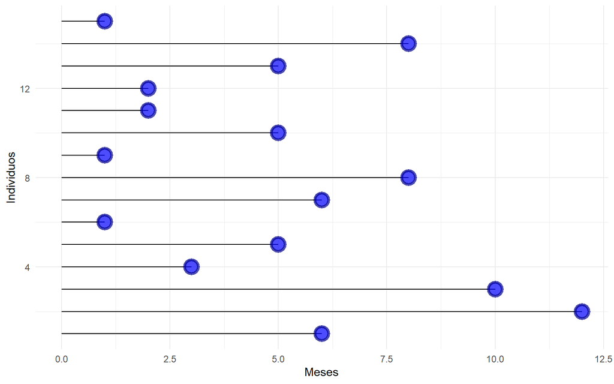

```r
aleitamentos=c(6,12,10,3,5,1,6,8,1,5,2,2,5,8,1)
meses=c(1,2,3,4,5,6,7,8,9,10,11,12,13,14,15)
require(tidyverse)

ggplot(NULL, aes(x=meses, y=aleitamentos)) +
  geom_segment( aes(x=meses, xend=meses, y=0, yend=aleitamentos)) +
  geom_point( size=5, color="darkblue", fill=alpha("blue", 0.3), alpha=0.7, shape=21, stroke=2)+coord_flip()+theme_minimal()+ylab("Meses")+xlab("Individuos")
```

2. Represente as trajetórias dos primeiros cinco indivíduos utilizando as variáveis N(t) e Y (t) do processo de contagem.
3. Como você construiria um banco de dados para analisar estes dados pelo processo clássico e de contagem?

```r
dados=data.frame(Individuo=c(1:15),Tempo=aleitamentos,Status=c(rep(1,15)))
require(DT)
datatable(dados,rownames = FALSE,options = list(searching = FALSE,
  initComplete = JS(
    "function(settings, json) {",
    "$(this.api().table().header()).css({'background-color': '#8EA8C3', 'color': '#fff'});",
    "}")
))%>% DT::formatStyle("Tempo",  color = 'white', backgroundColor = 'grey', fontWeight = 'bold') %>%DT::formatStyle('Individuo',  color = 'white', backgroundColor = 'grey', fontWeight = 'bold')%>% DT::formatStyle("Status",  color = 'white', backgroundColor = 'grey', fontWeight = 'bold') %>%DT::formatStyle('Individuo',  color = 'white', backgroundColor = 'grey', fontWeight = 'bold')
```

| Individuo | Tempo | Status |
| --- | --- | --- |
| 1 | 6 | 1 |
| 2 | 12 | 1 |
| 3 | 10 | 1 |
| 4 | 3 | 1 |
| 5 | 5 | 1 |
| 6 | 1 | 1 |
| 7 | 6 | 1 |
| 8 | 8 | 1 |
| 9 | 1 | 1 |
| 10 | 5 | 1 |

[output cut: 5 more lines]

**Exercício 1.2:** Considere agora o tempo de sobrevivência de 15 pacientes submetidos à hemodiálise. Neste caso, a variável de interesse ? o tempo desde a primeira diálise até o óbito (em meses). Repita os itens a,b e c do ex anterior.

**Exercício 1.3:** Considere os dados de 6 indivíduos em uma coorte para a avaliação de fatores de risco para a infecção por HIV. O estudo iniciou-se em 01/06/2008 quando 2 indivíduos entraram no estudo, com resultados negativos para a infecção. Um deles ao realizar o segundo exame, um m?s depois, teve resultado positivo, o outro positivou depois de 2 meses. Os outros 4 indivíduos realizaram seus primeiros exames em 01/07, 01/09, 01/08 e 01/08, e as suas respectivas datas de soroconversões foram 2, 3, 2 e 5 meses, após a entrada.

1. Construa a base de dados no formato clássico e de contagem.
2. Represente graficamente os tempos observados desses indivíduos
3. Que tipo de censura ocorreu no estudo?
4. Em que situação haveria truncamento?

**Exercício 1.4:** Para se familiarizar com o R e com o banco de dados do IPEC (ipec.csv, veja o Apêndice, seção AIDS ? clássico) que ser? utilizado nos próximos capítulos, inicie a an?lise de sobrevivência observando os dados dos pacientes:

1. No formato clássico;
2. No formato de processo de contagem;
3. Observe a saída nos dois formatos. Quais os tempos e status do 1o e 79o pacientes em cada um dos formatos?
4. Organize o banco e faça uma análise exploratória das variáveis de interesse:
   - Verifique as dimensções dos dados;
   - Veja quais são as variáveis que constam no arquivo de dados;
   - Substitua as informações ignoradas codificadas com 9/99 ou I por NA (padrão do R)
   - Indique ao R quais s?o as variáveis que estão erroneamente classificadas como numéricas pelo R (isso acontece quando números são usados para codificar as categorias).
   - Faça uma análise exploratória e descritiva das variáveis mais relevantes, usando medidas de sumarização, gráficos e diagramas.